# Self Regulation Ontology Retest Data Report

# Methods

## Loading and matching datasets

This report uses the variables that were designated as “meaningful” before. This is not the smallest subset where certain variables are dropped because they are correlated with other variables (within a task) and includes both accuracies as well as both kinds of DDM variables (EZ and HDDM). It will not include variables that were considered not of theoretical interest in the analyses of time 1 data. The variables that are not included will be listed for reference as well.

### Load time 1 data

```r
test_data <- read.csv('/Users/zeynepenkavi/Documents/PoldrackLabLocal/Self_Regulation_Ontology/Data/Complete_01-31-2017/meaningful_variables.csv')

test_data2 <- read.csv('/Users/zeynepenkavi/Documents/PoldrackLabLocal/Self_Regulation_Ontology/Data/Complete_01-31-2017/meaningful_variables_noDDM.csv')

test_data3 <- read.csv('/Users/zeynepenkavi/Documents/PoldrackLabLocal/Self_Regulation_Ontology/Data/Complete_01-31-2017/meaningful_variables_EZ.csv')

test_data <- merge(test_data, test_data2)
test_data <- merge(test_data, test_data3)
rm(test_data2, test_data3)
```

For reference here are the variables that are **not** included in the analyses of the remainder of this report because they were not of theoretical interest in factor structure analyses of this data so far. These include drift diffusion and other model parameters for specific conditions within a task; survey variables that are not part of the dependant variables for that survey in the literature and demographics (these are saved for prediction analyses).

```r
test_data2 <- read.csv('/Users/zeynepenkavi/Documents/PoldrackLabLocal/Self_Regulation_Ontology/Data/Complete_01-31-2017/variables_exhaustive.csv')

test_data2$X <- as.character(test_data2$X)

names(test_data2)[1] <- 'sub_id'

df <- data.frame(names(test_data2)[which(names(test_data2) %in% names(test_data) == FALSE)])
names(df) = c('vars')

df
```

| vars |
| --- |
| sub_id |
| adaptive_n_back.avg_rt_error |
| adaptive_n_back.missed_percent |
| adaptive_n_back.post_error_slowing |
| adaptive_n_back.std_rt |
| adaptive_n_back.std_rt_error |
| attention_network_task.EZ_drift_congruent |
| attention_network_task.EZ_drift_incongruent |
| attention_network_task.EZ_drift_neutral |
| attention_network_task.EZ_non_decision_congruent |

[output cut: 315 more lines]

### Load time 2 data

```r
retest_data <- read.csv('/Users/zeynepenkavi/Documents/PoldrackLabLocal/Self_Regulation_Ontology/Data/Retest_02-11-2017/meaningful_variables.csv')

retest_data2 <- read.csv('/Users/zeynepenkavi/Documents/PoldrackLabLocal/Self_Regulation_Ontology/Data/Retest_02-11-2017/meaningful_variables_noDDM.csv')

retest_data3 <- read.csv('/Users/zeynepenkavi/Documents/PoldrackLabLocal/Self_Regulation_Ontology/Data/Retest_02-11-2017/meaningful_variables_EZ.csv')

retest_data <- merge(retest_data, retest_data2)
retest_data <- merge(retest_data, retest_data3)
rm(retest_data2, retest_data3)
```

Extract t2 participants with good t1 data: We only invited those with good data but due to a technical error a handful of subjects who weren’t checked for data quality completed the retest battery as well. One of those subjects gave good t2 data but didn’t have good t1 data and therefore is removed from further analyses.

```r
#Process sub_id columns in the data dataframes
retest_data$X <- as.character(retest_data$X)
test_data$X <- as.character(test_data$X)

names(retest_data)[1] <- 'sub_id'
names(test_data)[1] <- 'sub_id'

retest_data <- retest_data[retest_data$sub_id %in% test_data$sub_id,]
```

### Clean t1 data

The cleaning functions here are translated from the python pipeline to mimick the same procedure that was applied to the `meaningful_variables` in creating `meaningful_variables_clean`.

The original cleaning procedures include three steps:  
1. Removing outliers for each variable where outliers are defined as those who are greater than 2.5 IQR from median. **This step is skipped here because removing outliers from either dataset could lead to an unnecessary increase in missing data. Since we are interested in the average distance between two measures of a metric for a given subject instead of the distance between all these metrics this seemed appropriate.**  
2. Removing correlated variables *within* a task. In creating `meaningful_variables_clean` if variables for a given task correlated >.85 only one was kept. **This step is skipped here because we want to look at the reliability of as many variables as we can.**  
3. Log transforming variables with skew. In cleaning t1 data variables that had a |skew| > 1 were log transformed and those for which skew could not be removed successfully were dropped. **Here we transform all variables that have a |skew|>1 in t1 data but variables that are not successfully transformed will be listed and not dropped.**

```r
remove_outliers = function(data_column, quantile_range = 2.5){

  q_25 = quantile(data_column, na.rm=T)[2]
  q_50 = quantile(data_column, na.rm=T)[3]
  q_75 = quantile(data_column, na.rm=T)[4]

  lowlimit = q_50 - quantile_range*(q_75 - q_25)
  highlimit = q_50 + quantile_range*(q_75 - q_25)

  data_column = ifelse(data_column<lowlimit, NA, ifelse(data_column>highlimit, NA, data_column))

  return(data_column)
}

"%w/o%" <- function(x, y) x[!x %in% y]

pos_log <- function(column){
  col_min = min(column, na.rm=T)
  a = 1-col_min
  column = column+a
  return(log(column))
}

neg_log <- function(column){
  col_max = max(column, na.rm=T)
  column = col_max+1-column
  return(log(column))
}

transform_remove_skew = function(data, columns, threshold = 1, drop=FALSE){

  tmp = as.data.frame(apply(data[,columns],2,skew))
  names(tmp) = c("skew")
  tmp$dv = row.names(tmp)
  tmp = tmp %>%
    filter(abs(skew)>threshold)

  skewed_variables = tmp$dv
  skew_subset = data[, skewed_variables]
  positive_subset = data[,tmp$dv[tmp$skew>0]]
  negative_subset = data[,tmp$dv[tmp$skew<0]]

  # transform variables
  # log transform for positive skew
  # positive_subset = log(positive_subset)
  positive_subset = pos_log(positive_subset) #slight divergence from original code
  successful_transforms = as.data.frame(apply(positive_subset, 2, skew))
  names(successful_transforms) = c('skew')
  successful_transforms$dv = row.names(successful_transforms)
  successful_transforms = successful_transforms %>% filter(abs(skew)<threshold)
  successful_transforms = successful_transforms$dv
  successful_transforms = positive_subset[,successful_transforms]
  dropped_vars = names(positive_subset) %w/o% names(successful_transforms)

  cat(rep('*', 40))
  cat('\n')
  cat(paste0(length(names(positive_subset)) ,' data positively skewed data were transformed:'))
  cat('\n')
  cat(names(positive_subset), sep = '\n')
  cat(rep('*', 40))
  cat('\n')

  # replace transformed variables
  data = data[,-c(which(names(data) %in% names(positive_subset)))]

  if(drop == TRUE){
    names(successful_transforms) = paste0(names(successful_transforms), '.logTr')
    cat(rep('*', 40))
    cat('\n')
    cat(paste0('Dropping ', length(dropped_vars) ,' positively skewed data that could not be transformed successfully:'))
    cat('\n')
    cat(dropped_vars, sep = '\n')
    cat(rep('*', 40))
    cat('\n')
    data = cbind(data, successful_transforms)
  }
  else{
    names(positive_subset) = paste0(names(positive_subset), '.logTr')
    cat(rep('*', 40))
    cat('\n')
    cat(paste0(length(dropped_vars) ,' positively skewed data could not be transformed successfully:'))
    cat('\n')
    cat(dropped_vars, sep = '\n')
    cat(rep('*', 40))
    cat('\n')
    data = cbind(data, positive_subset)
  }


  # reflected log transform for negative skew
  negative_subset = as.data.frame(apply(negative_subset, 2, neg_log))
  successful_transforms = as.data.frame(apply(negative_subset, 2, skew))
  names(successful_transforms) = c('skew')
  successful_transforms$dv = row.names(successful_transforms)
  successful_transforms = successful_transforms %>% filter(abs(skew)<1)
  successful_transforms = successful_transforms$dv
  successful_transforms = negative_subset[,successful_transforms]
  dropped_vars = names(negative_subset) %w/o% names(successful_transforms)

  cat(rep('*', 40))
  cat('\n')
  cat(paste0(length(names(negative_subset)) ,' data negatively skewed data were transformed:'))
  cat('\n')
  cat(names(negative_subset), sep = '\n')
  cat(rep('*', 40))
  cat('\n')

  # replace transformed variables
  data = data[,-c(which(names(data) %in% names(negative_subset)))]
  if(drop == TRUE){
    names(successful_transforms) = paste0(names(successful_transforms), '.ReflogTr')
    cat(rep('*', 40))
    cat('\n')
    cat(paste0('Dropping ', length(dropped_vars) ,' negatively skewed data that could not be transformed successfully:'))
    cat('\n')
    cat(dropped_vars, sep = '\n')
    cat(rep('*', 40))
    cat('\n')
    data = cbind(data, successful_transforms)
  }
  else{
    names(negative_subset) = paste0(names(negative_subset), '.ReflogTr')
    cat(rep('*', 40))
    cat('\n')
    cat(paste0(length(dropped_vars) ,' negatively skewed data could not be transformed successfully:'))
    cat('\n')
    cat(dropped_vars, sep = '\n')
    cat(rep('*', 40))
    cat('\n')
    data = cbind(data, negative_subset)
  }

  return(data)
}
```

Clean t1 data on full sample without dropping any columns. Columns that are not transformed successfully are listed.

```r
numeric_cols = c()

for(i in 1:length(names(test_data))){
  if(is.numeric(test_data[,i])){
    numeric_cols <- c(numeric_cols, names(test_data)[i])
  }
}

# clean_test_data = cbind(sub_id = test_data$sub_id, as.data.frame(apply(test_data[, -which(names(test_data) %in% c("sub_id"))], 2, remove_outliers)))

# clean_test_data = transform_remove_skew(clean_test_data, numeric_cols)
clean_test_data = transform_remove_skew(test_data, numeric_cols)
```

```
* * * * * * * * * * * * * * * * * * * * * * * * * * * * * * * * * * * * * * * *
44 data positively skewed data were transformed:
adaptive_n_back.mean_load
bickel_titrator.hyp_discount_rate_large
bickel_titrator.hyp_discount_rate_medium
bickel_titrator.hyp_discount_rate_small
bis11_survey.Motor
columbia_card_task_cold.gain_sensitivity
columbia_card_task_hot.gain_sensitivity
dickman_survey.dysfunctional
dospert_eb_survey.health_safety
impulsive_venture_survey.impulsiveness
kirby.hyp_discount_rate_large
kirby.hyp_discount_rate_medium
kirby.hyp_discount_rate_small
motor_selective_stop_signal.selective_proactive_control
simple_reaction_time.avg_rt
stop_signal.SSRT_high
stop_signal.SSRT_low
tower_of_london.avg_move_time
choice_reaction_time.hddm_thresh
directed_forgetting.proactive_interference_hddm_drift
dot_pattern_expectancy.hddm_thresh
motor_selective_stop_signal.hddm_thresh
shape_matching.hddm_thresh
stim_selective_stop_signal.hddm_thresh
stop_signal.hddm_thresh
stroop.hddm_thresh
threebytwo.hddm_thresh
attention_network_task.conflict_rt
choice_reaction_time.avg_rt
directed_forgetting.proactive_interference_acc
dot_pattern_expectancy.avg_rt
shape_matching.avg_rt
simon.avg_rt
threebytwo.avg_rt
threebytwo.cue_switch_cost_rt_100.0
threebytwo.cue_switch_cost_rt_900.0
adaptive_n_back.EZ_drift
adaptive_n_back.EZ_thresh
```

[output cut: 98 more lines]

```
dot_pattern_expectancy.BX.BY_rt
dot_pattern_expectancy.acc
go_nogo.acc
information_sampling_task.Fixed_Win_acc
local_global_letter.acc
psychological_refractory_period_two_choices.task1_acc
psychological_refractory_period_two_choices.task2_acc
recent_probes.acc
shape_matching.acc
simon.acc
simon.simon_acc
stroop.acc
stroop.stroop_acc
stim_selective_stop_signal.EZ_non_decision
* * * * * * * * * * * * * * * * * * * * * * * * * * * * * * * * * * * * * * * *
```

### Clean t2 data

Instead of applying the same functions applied to t1 data we check which variables are transformed in what way and transform the t2 data the same way. Again we are not removing outliers in the t2 or dropping variables if the skew is not removed successfully after transforming.

Get list of transformed variables and the sign of their skew

```r
logTr_vars = data.frame(grep('logTr', names(clean_test_data), value=T))
names(logTr_vars) = c('var')
logTr_vars$sign = ifelse(grepl(".ReflogTr",logTr_vars$var), 'negative', 'positive')
logTr_vars$var = gsub(".logTr|.ReflogTr", "", logTr_vars$var)
```

Transform the t2 columns the same way t1 columns were transformed.

```r
clean_retest_data = retest_data

for(i in 1:length(names(clean_retest_data))){
  tmp_col = names(clean_retest_data)[i]
  if(tmp_col %in% logTr_vars$var){
    sign = logTr_vars$sign[which(tmp_col == logTr_vars$var)]
      if(sign == 'positive'){
        # clean_retest_data[,tmp_col] = log(clean_retest_data[,tmp_col])
        clean_retest_data[,tmp_col] = pos_log(clean_retest_data[,tmp_col])
        names(clean_retest_data)[which(names(clean_retest_data) == tmp_col)] = paste0(tmp_col, '.logTr')
        cat(paste0(tmp_col ,' was positively skewed and transformed.'))
        cat('\n')
      }
      else if(sign == 'negative'){
        clean_retest_data[,tmp_col] = neg_log(clean_retest_data[,tmp_col])
        names(clean_retest_data)[which(names(clean_retest_data) == tmp_col)] = paste0(tmp_col, '.ReflogTr')
        cat(paste0(tmp_col ,' was negatively skewed and transformed.'))
        cat('\n')
      }
    }
}
```

```
adaptive_n_back.mean_load was positively skewed and transformed.
bickel_titrator.hyp_discount_rate_large was positively skewed and transformed.
bickel_titrator.hyp_discount_rate_medium was positively skewed and transformed.
bickel_titrator.hyp_discount_rate_small was positively skewed and transformed.
bis11_survey.Motor was positively skewed and transformed.
columbia_card_task_cold.gain_sensitivity was positively skewed and transformed.
columbia_card_task_hot.gain_sensitivity was positively skewed and transformed.
columbia_card_task_hot.loss_sensitivity was negatively skewed and transformed.
dickman_survey.dysfunctional was positively skewed and transformed.
dospert_eb_survey.health_safety was positively skewed and transformed.
impulsive_venture_survey.impulsiveness was positively skewed and transformed.
kirby.hyp_discount_rate_large was positively skewed and transformed.
kirby.hyp_discount_rate_medium was positively skewed and transformed.
kirby.hyp_discount_rate_small was positively skewed and transformed.
motor_selective_stop_signal.selective_proactive_control was positively skewed and transformed.
mpq_control_survey.control was negatively skewed and transformed.
selection_optimization_compensation_survey.optimization was negatively skewed and transformed.
simple_reaction_time.avg_rt was positively skewed and transformed.
stop_signal.SSRT_high was positively skewed and transformed.
stop_signal.SSRT_low was positively skewed and transformed.
ten_item_personality_survey.conscientiousness was negatively skewed and transformed.
tower_of_london.avg_move_time was positively skewed and transformed.
attention_network_task.conflict_hddm_drift was negatively skewed and transformed.
attention_network_task.hddm_non_decision was negatively skewed and transformed.
choice_reaction_time.hddm_non_decision was negatively skewed and transformed.
choice_reaction_time.hddm_thresh was positively skewed and transformed.
directed_forgetting.proactive_interference_hddm_drift was positively skewed and transformed.
dot_pattern_expectancy.hddm_thresh was positively skewed and transformed.
motor_selective_stop_signal.hddm_non_decision was negatively skewed and transformed.
motor_selective_stop_signal.hddm_thresh was positively skewed and transformed.
shape_matching.hddm_non_decision was negatively skewed and transformed.
shape_matching.hddm_thresh was positively skewed and transformed.
stim_selective_stop_signal.hddm_non_decision was negatively skewed and transformed.
stim_selective_stop_signal.hddm_thresh was positively skewed and transformed.
stop_signal.hddm_non_decision was negatively skewed and transformed.
stop_signal.hddm_thresh was positively skewed and transformed.
stroop.hddm_thresh was positively skewed and transformed.
threebytwo.hddm_thresh was positively skewed and transformed.
adaptive_n_back.acc was negatively skewed and transformed.
attention_network_task.acc was negatively skewed and transformed.
```

[output cut: 26 more lines]

```
stroop.stroop_acc was negatively skewed and transformed.
threebytwo.avg_rt was positively skewed and transformed.
threebytwo.cue_switch_cost_rt_100.0 was positively skewed and transformed.
threebytwo.cue_switch_cost_rt_900.0 was positively skewed and transformed.
adaptive_n_back.EZ_drift was positively skewed and transformed.
adaptive_n_back.EZ_thresh was positively skewed and transformed.
attention_network_task.conflict_EZ_drift was negatively skewed and transformed.
attention_network_task.conflict_EZ_non_decision was positively skewed and transformed.
directed_forgetting.EZ_non_decision was positively skewed and transformed.
local_global_letter.conflict_EZ_drift was negatively skewed and transformed.
motor_selective_stop_signal.EZ_thresh was positively skewed and transformed.
stim_selective_stop_signal.EZ_non_decision was negatively skewed and transformed.
stim_selective_stop_signal.EZ_thresh was positively skewed and transformed.
stroop.EZ_non_decision was positively skewed and transformed.
threebytwo.EZ_non_decision was positively skewed and transformed.
```

Check transformations are correct

```r
retest_logTr_vars = data.frame(grep('logTr', names(clean_retest_data), value=T))
names(retest_logTr_vars) = c('var')
retest_logTr_vars$sign = ifelse(grepl(".ReflogTr",retest_logTr_vars$var), 'negative', 'positive')
retest_logTr_vars$var = gsub(".logTr|.ReflogTr", "", retest_logTr_vars$var)
retest_logTr_vars = retest_logTr_vars %>% arrange(var)
logTr_vars = logTr_vars %>% arrange(var)
retest_logTr_vars == logTr_vars
```

```
       var sign
 [1,] TRUE TRUE
 [2,] TRUE TRUE
 [3,] TRUE TRUE
 [4,] TRUE TRUE
 [5,] TRUE TRUE
 [6,] TRUE TRUE
 [7,] TRUE TRUE
 [8,] TRUE TRUE
 [9,] TRUE TRUE
[10,] TRUE TRUE
[11,] TRUE TRUE
[12,] TRUE TRUE
[13,] TRUE TRUE
[14,] TRUE TRUE
```

[output cut: 67 more lines]

```r
# Switch df names
raw_retest_data = retest_data
raw_test_data = test_data
test_data = clean_test_data
retest_data = clean_retest_data
rm(clean_test_data, clean_retest_data)
```

### Extract t-1 data for t-2 subjects

```r
retest_subs_test_data <- test_data[test_data$sub_id %in% retest_data$sub_id,]

rest_subs_test_data <- test_data[test_data$sub_id %in% retest_data$sub_id == FALSE,]

#Arrange datasets of same size by sub_id
retest_data = retest_data %>% arrange(sub_id)
retest_subs_test_data = retest_subs_test_data %>% arrange(sub_id)

#CHECK IF EVERYTHING IS ORDERED RIGHT
as.character(retest_subs_test_data$sub_id) == as.character(retest_data$sub_id)
```

```
  [1] TRUE TRUE TRUE TRUE TRUE TRUE TRUE TRUE TRUE TRUE TRUE TRUE TRUE TRUE
 [15] TRUE TRUE TRUE TRUE TRUE TRUE TRUE TRUE TRUE TRUE TRUE TRUE TRUE TRUE
 [29] TRUE TRUE TRUE TRUE TRUE TRUE TRUE TRUE TRUE TRUE TRUE TRUE TRUE TRUE
 [43] TRUE TRUE TRUE TRUE TRUE TRUE TRUE TRUE TRUE TRUE TRUE TRUE TRUE TRUE
 [57] TRUE TRUE TRUE TRUE TRUE TRUE TRUE TRUE TRUE TRUE TRUE TRUE TRUE TRUE
 [71] TRUE TRUE TRUE TRUE TRUE TRUE TRUE TRUE TRUE TRUE TRUE TRUE TRUE TRUE
 [85] TRUE TRUE TRUE TRUE TRUE TRUE TRUE TRUE TRUE TRUE TRUE TRUE TRUE TRUE
 [99] TRUE TRUE TRUE TRUE TRUE TRUE TRUE TRUE TRUE TRUE TRUE TRUE TRUE TRUE
[113] TRUE TRUE TRUE TRUE TRUE TRUE TRUE TRUE TRUE TRUE TRUE TRUE TRUE TRUE
[127] TRUE TRUE TRUE TRUE TRUE TRUE TRUE TRUE TRUE TRUE TRUE TRUE TRUE TRUE
[141] TRUE TRUE TRUE TRUE TRUE TRUE TRUE
```

# Results

## Correlations for all cleaned meaningful variables

Spearman only

```r
numeric_cols = c()

for(i in 1:length(names(test_data))){
  if(is.numeric(test_data[,i])){
    numeric_cols <- c(numeric_cols, names(test_data)[i])
  }
}

cor_df <- data.frame(spearman = rep(NA, length(numeric_cols)))

row.names(cor_df) <- numeric_cols

for(i in 1:length(numeric_cols)){
  cor_df[numeric_cols[i], 'spearman'] <- cor(retest_data[,numeric_cols[i]],retest_subs_test_data[,numeric_cols[i]], method = 'spearman', use = "pairwise.complete.obs")
}
```

Distribution of Spearman correlations

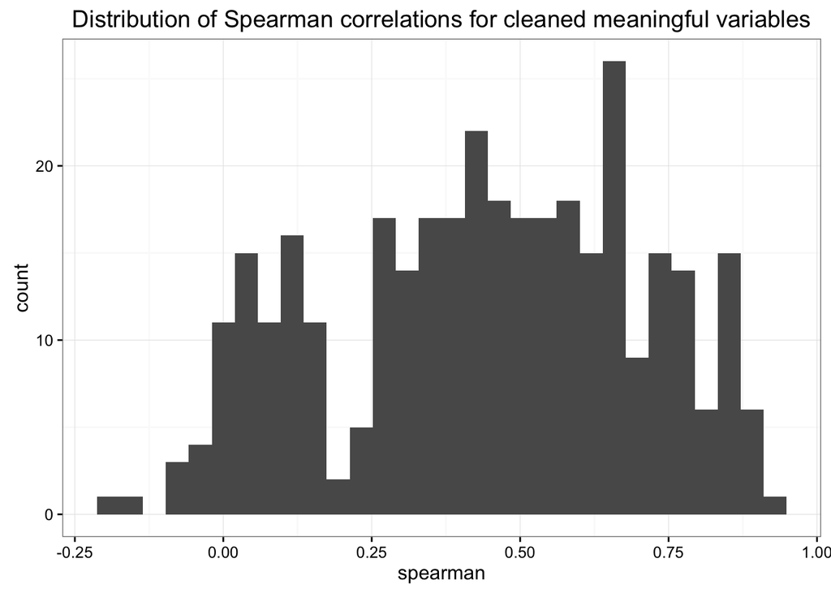

```r
cor_df %>%
  ggplot(aes(spearman))+
  geom_histogram()+
  theme_bw()+
  ggtitle('Distribution of Spearman correlations for cleaned meaningful variables')
```

```r
# Add column to tasks vs. surveys in correlation table
cor_df$dv = row.names(cor_df)
row.names(cor_df) = seq(1:nrow(cor_df))
cor_df$task = 'task'
cor_df[grep('survey', cor_df$dv), 'task'] = 'survey'
```

### Distributions of correlations by task vs. survey

Spearman correlations for surveys are noticably higher than task reliabilities.

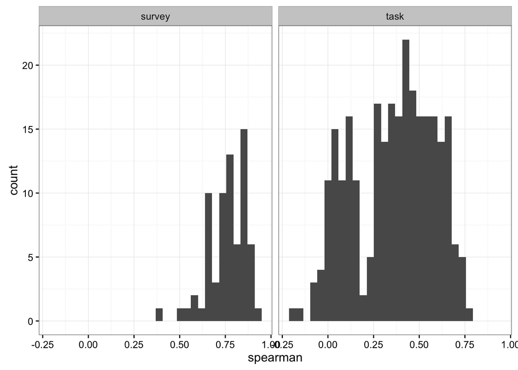

```r
cor_df %>%
  ggplot(aes(spearman))+
  geom_histogram()+
  theme_bw()+
  facet_wrap(~task)
```

Mean Spearman correlation and the number of variables for both the surveys and the tasks

```r
cor_df %>%
  group_by(task) %>%
  summarise(mean_spearman = mean(spearman),
            num_vars = n())
```

| task | mean_spearman | num_vars |
| --- | --- | --- |
| survey | 0.7613 | 70 |
| task | 0.3596 | 274 |

#### Rank order of correlations

##### For tasks

```r
cor_df %>%
  filter(task == 'task') %>%
  select(dv, spearman) %>%
  arrange(-spearman)
```

| dv | spearman |
| --- | --- |
| ravens.score | 0.783004 |
| kirby.hyp_discount_rate_large.logTr | 0.749964 |
| adaptive_n_back.mean_load.logTr | 0.743475 |
| kirby.hyp_discount_rate_medium.logTr | 0.731841 |
| kirby.hyp_discount_rate_small.logTr | 0.728892 |
| adaptive_n_back.avg_rt | 0.717112 |
| attention_network_task.avg_rt | 0.705910 |
| information_sampling_task.Fixed_Win_motivation | 0.704799 |
| stroop.avg_rt | 0.699190 |
| tower_of_london.avg_move_time.logTr | 0.697115 |

[output cut: 264 more lines]

##### For surveys

- Demographics are excluded from this list of variables.
- Holt and Laury test-retest is the worst for *surveys*. But note that this is not a survey that has been studied extensively psychometrically like others. This is more similar to our tasks (one that is used more often by economists). In previous data I have worked with retest reliablities for this task was ~.35 so the results here are in line with this.
- Otherwise the lowest survey reliabilities are 0.5.

```r
cor_df %>%
  filter(task == 'survey') %>%
  select(dv, spearman) %>%
  arrange(-spearman)
```

| dv | spearman |
| --- | --- |
| ten_item_personality_survey.extraversion | 0.9130 |
| self_regulation_survey.control | 0.9034 |
| bis_bas_survey.BIS | 0.8967 |
| grit_scale_survey.grit | 0.8865 |
| upps_impulsivity_survey.sensation_seeking | 0.8844 |
| brief_self_control_survey.self_control | 0.8830 |
| ten_item_personality_survey.emotional_stability | 0.8820 |
| five_facet_mindfulness_survey.describe | 0.8684 |
| dospert_rt_survey.recreational | 0.8652 |
| time_perspective_survey.past_negative | 0.8616 |

[output cut: 60 more lines]

## ICC for all cleaned meaningful variables

Based on [Weir (2005)](https://pdfs.semanticscholar.org/d99a/790cce43f7f20d742f9d379b79de4f767740.pdf) ICC(3,k) does not take in to account within subject differences between two time points (i.e. the fixed effect of time/systematic error). Thus, it is well approximated by Pearson’s r and subject to similar criticisms. [Weir (2005)](https://pdfs.semanticscholar.org/d99a/790cce43f7f20d742f9d379b79de4f767740.pdf) suggests reporting at least this systematic error effect size if one chooses to report with ICC(3,k). Based on his conclusions here I report:  
- ICC(3,k): ranges between 0-1; the larger the better  
- partial $\eta^2$ for time ($SS_{time}/SS_{within}$): effect size of time  
- SEM ($\sqrt(MS_{error})$): standard error of measurement; the smaller the better

```r
match_t1_t2 <- function(dv_var, t1_df = test_data, t2_df = retest_data, merge_var = 'sub_id'){
  df = merge(t1_df[,c(merge_var, dv_var)], t2_df[,c(merge_var, dv_var)], by = merge_var)
  df = df %>%
    na.omit()%>%
    gather(dv, score, -sub_id) %>%
    mutate(time = ifelse(grepl('\\.x', dv), 1, ifelse(grepl('\\.y', dv), 2, NA))) %>%
    separate(dv, c("dv", "drop"), sep='\\.([^.]*)$') %>%
    select(-drop)
   return(df)
}

get_icc <- function(dv_var, t1_df = test_data, t2_df = retest_data, merge_var = 'sub_id'){
  df = match_t1_t2(dv_var, t1_df = t1_df, t2_df = t2_df, merge_var = merge_var)
  df = df %>% spread(time, score) %>% select(-dv, -sub_id)
  icc = ICC(df)
  icc_3k = icc$results['Average_fixed_raters', 'ICC']
  return(icc_3k)
  }

get_eta <- function(dv_var, t1_df = test_data, t2_df = retest_data, merge_var = 'sub_id'){
  df = match_t1_t2(dv_var, t1_df = t1_df, t2_df = t2_df, merge_var = merge_var)
  mod = summary(aov(score~Error(sub_id)+time, df))
  ss_time = as.data.frame(unlist(mod$`Error: Within`))['Sum Sq1',]
  ss_error = as.data.frame(unlist(mod$`Error: Within`))['Sum Sq2',]
  eta = ss_time/(ss_time+ss_error)
  return(eta)
  }

get_sem <- function(dv_var, t1_df = test_data, t2_df = retest_data, merge_var = 'sub_id'){
  df = match_t1_t2(dv_var, t1_df = t1_df, t2_df = t2_df, merge_var = merge_var)
  mod = summary(aov(score~Error(sub_id)+time, df))
  ms_error = as.data.frame(unlist(mod$`Error: Within`))['Mean Sq2',]
  sem = sqrt(ms_error)
  return(sem)
}
```

```r
icc_df <- data.frame(icc = rep(NA, length(numeric_cols)),
                     eta_sq = rep(NA, length(numeric_cols)),
                     sem = rep(NA, length(numeric_cols)))

row.names(icc_df) <- numeric_cols

for(i in 1:length(numeric_cols)){
  icc_df[numeric_cols[i], 'icc'] <- get_icc(numeric_cols[i])
  icc_df[numeric_cols[i], 'eta_sq'] <- get_eta(numeric_cols[i])
  icc_df[numeric_cols[i], 'sem'] <- get_sem(numeric_cols[i])
}
```

Add column to tasks vs. surveys in icc table

```r
icc_df$dv = row.names(icc_df)
row.names(icc_df) = seq(1:nrow(icc_df))
icc_df$task = 'task'
icc_df[grep('survey', icc_df$dv), 'task'] = 'survey'
icc_df = icc_df %>%
  select(dv, task, icc, eta_sq, sem)
row.names(icc_df) = NULL
icc_df
```

| dv | task | icc | eta_sq | sem |
| --- | --- | --- | --- | --- |
| angling_risk_task_always_sunny.keep_adjusted_clicks | task | 0.5084376 | 1.867e-02 | 9.204e+00 |
| angling_risk_task_always_sunny.keep_loss_percent | task | 0.4578803 | 2.529e-02 | 9.483e-02 |
| angling_risk_task_always_sunny.keep_score | task | 0.2827694 | 2.037e-03 | 1.763e+02 |
| angling_risk_task_always_sunny.release_adjusted_clicks | task | 0.3686172 | 1.405e-03 | 7.271e+00 |
| angling_risk_task_always_sunny.release_loss_percent | task | 0.4814958 | 1.027e-03 | 9.733e-02 |
| angling_risk_task_always_sunny.release_score | task | 0.2063563 | 4.729e-04 | 1.239e+02 |
| bis11_survey.Attentional | survey | 0.8774876 | 3.795e-03 | 5.109e-01 |
| bis11_survey.Nonplanning | survey | 0.8875042 | 4.809e-03 | 4.166e-01 |
| bis_bas_survey.BAS_drive | survey | 0.8755021 | 1.361e-03 | 3.269e-01 |
| bis_bas_survey.BAS_fun_seeking | survey | 0.8988158 | 5.056e-02 | 2.876e-01 |

[output cut: 334 more lines]

### Distributions of ICC’s by task vs. survey

Survey reliabilities are noticably higher than task reliabilities.

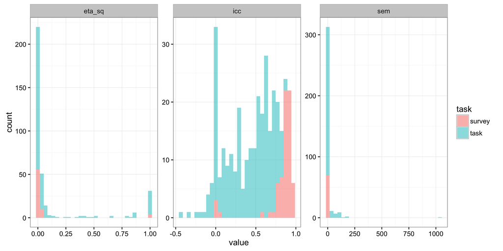

```r
icc_df %>%
  gather(key,value,-dv, -task) %>%
  ggplot(aes(value, fill=task))+
  geom_histogram(position = 'stack', alpha=0.5)+
  theme_bw()+
  facet_wrap(~key,scales='free')
```

Median reliability and the number of variables for both the surveys and the tasks

```r
icc_df %>%
  group_by(task) %>%
  summarise(median_icc = median(icc),
            median_eta_sq = median(eta_sq),
            median_sem = median(sem),
            num_vars = n())
```

| task | median_icc | median_eta_sq | median_sem | num_vars |
| --- | --- | --- | --- | --- |
| survey | 0.8776 | 0.003469 | 0.3522 | 70 |
| task | 0.4586 | 0.010754 | 0.2571 | 274 |

Sort tasks by icc. What’s going on with the negative icc’s? ICC(3,k) would be negative if the $MS_{error}$>$MS_{between}$

Plot their data scatter plots.

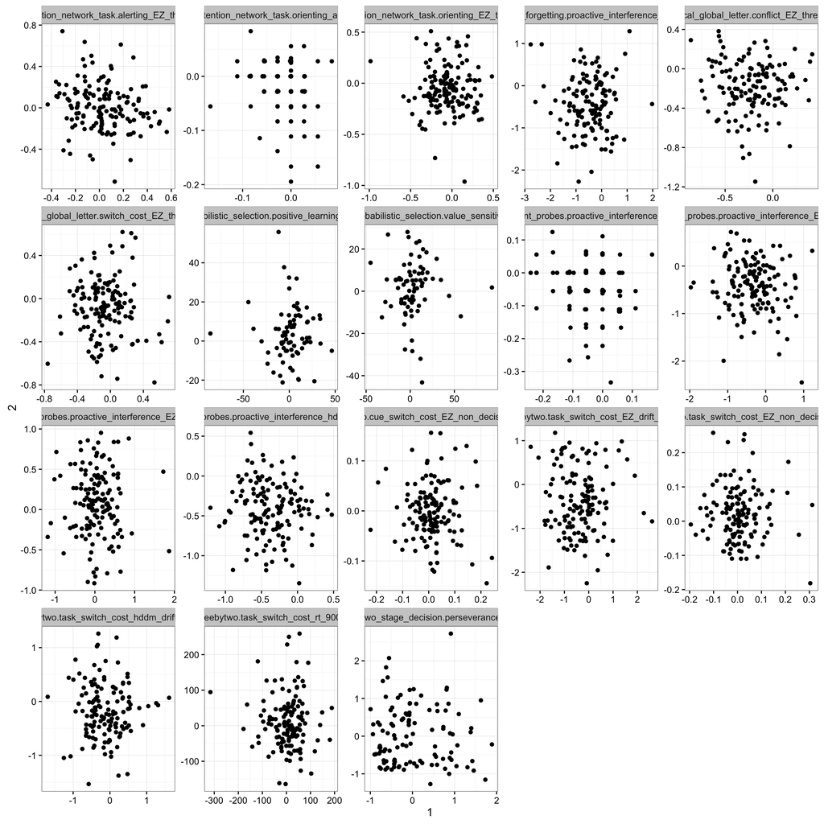

```r
neg_icc_vars = icc_df %>%
  arrange(icc) %>%
  filter(icc<0) %>%
  select(dv)

tmp = data.frame()

for(i in 1:nrow(neg_icc_vars)){
  tmp = rbind(tmp, match_t1_t2(neg_icc_vars$dv[i]))
}
rm(neg_icc_vars)

tmp %>%
  spread(time, score) %>%
  ggplot(aes(`1`, `2`))+
  geom_point()+
  theme_bw()+
  facet_wrap(~dv, scales='free')
```

Compare these plots to the variables with highest icc

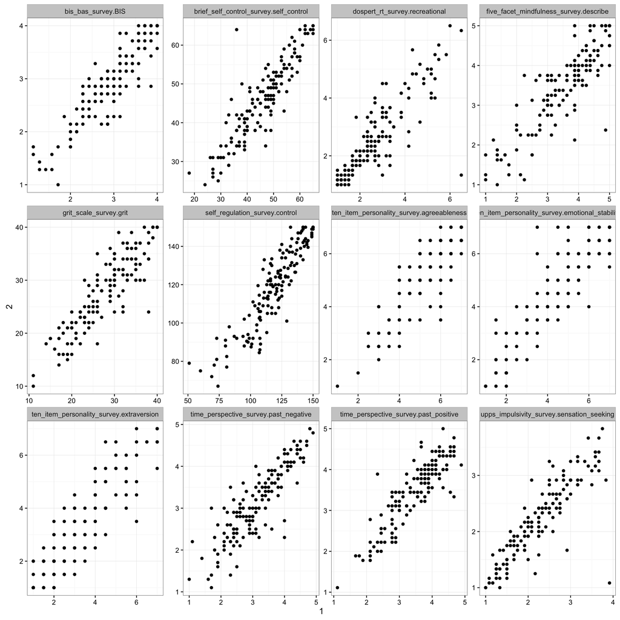

```r
high_icc_vars = icc_df %>%
  arrange(-icc)  %>%
  filter(icc>0.92) %>%
  select(dv)

tmp = data.frame()

for(i in 1:nrow(high_icc_vars)){
  tmp = rbind(tmp, match_t1_t2(high_icc_vars$dv[i]))
}
rm(high_icc_vars)

tmp %>%
  spread(time, score) %>%
  ggplot(aes(`1`, `2`))+
  geom_point()+
  theme_bw()+
  facet_wrap(~dv, scales='free')
```

### Relationship between ICC and Spearman

Mostly linear except for a bunch of tasks that have an icc ~ 0.

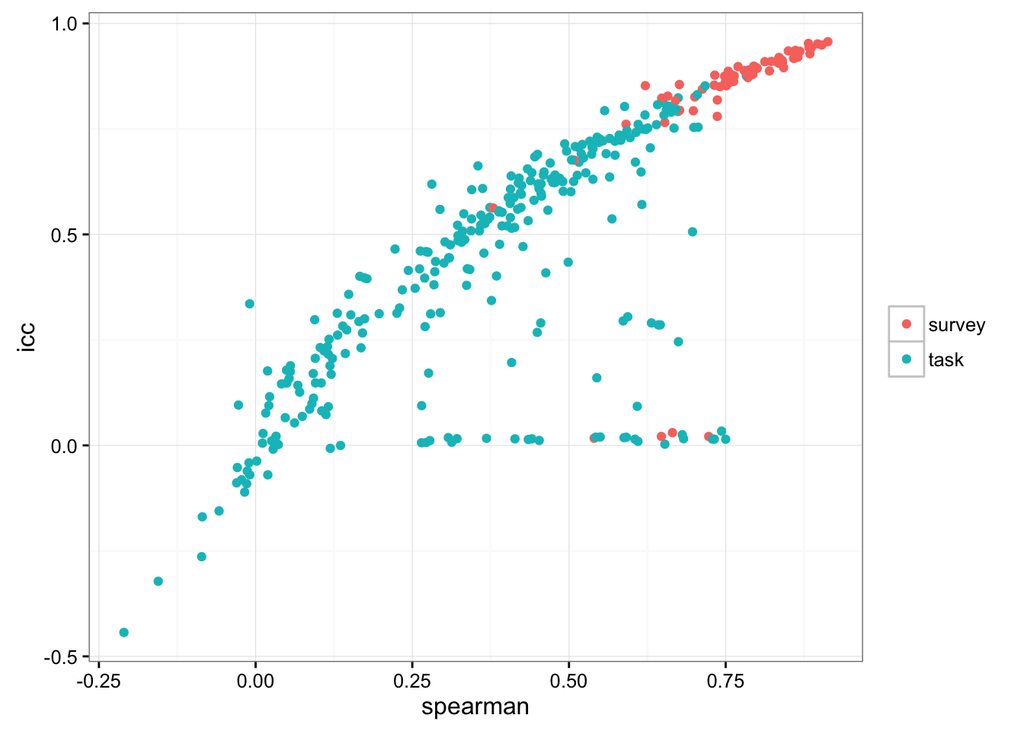

```r
icc_df %>%
  left_join(cor_df[,c('spearman','dv')], by = 'dv') %>%
  ggplot(aes(spearman, icc, col=task))+
  geom_point()+
  theme_bw()+
  theme(legend.title = element_blank())
```

What are the variables clustered around 0 ICC?

```r
icc_df %>%
  filter(icc>(-0.1), icc<0.1) %>%
  arrange(icc)
```

| dv | task | icc | eta_sq | sem |
| --- | --- | --- | --- | --- |
| threebytwo.task_switch_cost_EZ_non_decision_900.0 | task | -0.0907728 | 1.590e-02 | 0.08111 |
| local_global_letter.conflict_EZ_thresh | task | -0.0888202 | 9.608e-03 | 0.26635 |
| attention_network_task.orienting_EZ_thresh | task | -0.0815276 | 1.449e-04 | 0.22611 |
| threebytwo.task_switch_cost_rt_900.0 | task | -0.0697389 | 5.143e-03 | 71.74249 |
| two_stage_decision.perseverance | task | -0.0696833 | 2.596e-05 | 0.75612 |
| recent_probes.proactive_interference_EZ_thresh | task | -0.0607811 | 3.044e-03 | 0.43229 |
| threebytwo.task_switch_cost_hddm_drift_900.0 | task | -0.0524717 | 4.106e-03 | 0.51425 |
| local_global_letter.switch_cost_EZ_thresh | task | -0.0411980 | 3.176e-03 | 0.26189 |
| threebytwo.task_switch_cost_EZ_drift_900.0 | task | -0.0372184 | 1.027e-03 | 0.78741 |
| directed_forgetting.proactive_interference_EZ_drift | task | -0.0088922 | 1.559e-03 | 0.68986 |

[output cut: 49 more lines]

### Relationship between ICC and $\eta^2$

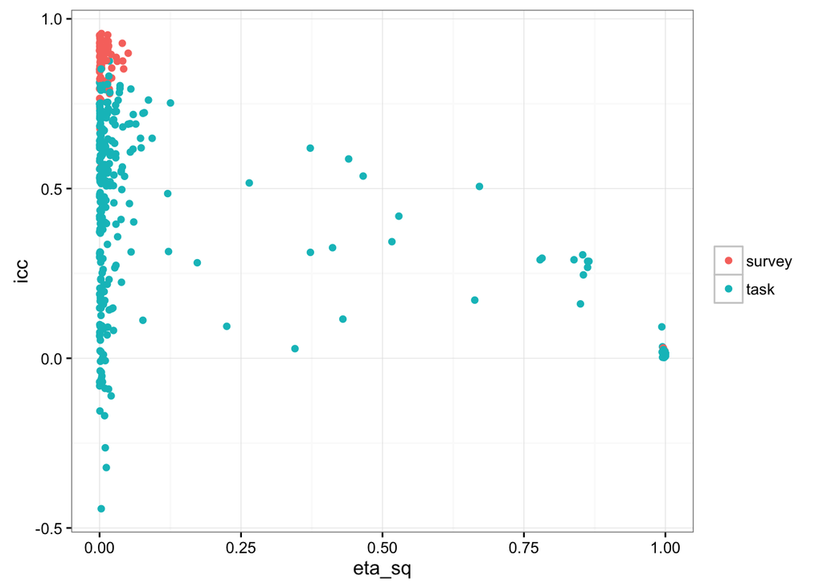

```r
icc_df %>%
  ggplot(aes(eta_sq, icc, col=task))+
  geom_point()+
  theme_bw()+
  theme(legend.title = element_blank())
```

Which tasks show a systematic difference between t1 and t2? Are these the tasks where the ICC and Spearman imply different conclusions?

```r
icc_df %>%
  select(dv, eta_sq) %>%
  arrange(-eta_sq)
```

| dv | eta_sq |
| --- | --- |
| attention_network_task.conflict_EZ_non_decision.logTr | 9.999e-01 |
| threebytwo.EZ_non_decision.logTr | 9.998e-01 |
| kirby.hyp_discount_rate_medium.logTr | 9.998e-01 |
| stroop.EZ_non_decision.logTr | 9.998e-01 |
| kirby.hyp_discount_rate_small.logTr | 9.998e-01 |
| directed_forgetting.proactive_interference_acc.logTr | 9.998e-01 |
| kirby.hyp_discount_rate_large.logTr | 9.998e-01 |
| columbia_card_task_cold.gain_sensitivity.logTr | 9.997e-01 |
| directed_forgetting.EZ_non_decision.logTr | 9.997e-01 |
| columbia_card_task_hot.gain_sensitivity.logTr | 9.996e-01 |

[output cut: 334 more lines]